# How to Sample Random Crosslink Distances

Mike Trnka

3/19/2021

### Measuring Euclidean Distances in R w/ Bio3d library

I make use of the Bio3d R package developed by the Grant Lab at UCSD. http://thegrantlab.org/bio3d/

To use these functions at home, copy into RStudio and execute within that environment. You need RStudio installed and extremely basic knowledge of how to use it: https://rstudio.com/products/rstudio/download/

https://rafalab.github.io/dsbook/getting-started.html

Need to install and load bio3d package as well as tidyverse package if not already installed:

```r
install.packages("tidyverse",
                 dependencies = T,
                 repos = "http://cran.us.r-project.org")
install.packages("bio3d",
                 dependencies = T,
                 repos = "http://cran.us.r-project.org")
```

Once installed load these libraries:

```r
library(tidyverse)
library(bio3d)
```

Heres is my function that reads a PDB from the database when given a valid PDB accession:

```r
parsePDB <- function(pdbid, pdbFileDir=getwd()) {
    if (file.exists(file.path(pdbFileDir, pdbid))) {
        pdbCode <- file.path(pdbFileDir, pdbid)
    } else {
        pdbCode = str_extract(pdbid, "^[[0-9A-Za-z]]{4}")
    }
    if (is.na(pdbCode)) message(str_c(pdbid, " is not a valid pdb id"))
    fileExtention <- str_extract(pdbid, "(?<=\\.)[[^\\.]]+$")
    if (!fileExtention %in% c("cif", "pdb")) fileExtention <- "pdb"
    parsedPDB <- tryCatch(
        switch(fileExtention,
               "cif" = bio3d::read.cif(pdbCode, verbose=F),
               "pdb" = bio3d::read.pdb(pdbCode, verbose=F)
        ),
        error = function(e) {
            message(str_c("Trouble reading pdb id: ", pdbid, "\n", e))
            return(NA)
        }
    )
    if (!file.exists(file.path(pdbFileDir, pdbid)) & ("pdb" %in% class(parsedPDB))) {
        bio3d::write.pdb(parsedPDB, file.path(pdbFileDir, str_c(pdbCode, ".pdb")))
    }
    ca.ind <- bio3d::atom.select(parsedPDB, "calpha")
    parsedPDB <- parsedPDB$atom[ca.ind$atom,]
    return(parsedPDB)
}
```

Let’s download coordinates for RNA polymerase II (yeast):

```r
polII <- parsePDB("1wcm")
```

```
##   Note: Accessing on-line PDB file
```

This function strips out the relevant portion of the PDB file making a data.frame of c-alpha coordinates like so:

```r
head(polII)
```

```
##    type eleno elety  alt resid chain resno insert       x      y       z o
## 2  ATOM     2    CA <NA>   VAL     A     2   <NA> 114.370 27.980 -26.088 1
## 9  ATOM     9    CA <NA>   GLY     A     3   <NA> 111.506 26.368 -28.075 1
## 13 ATOM    13    CA <NA>   GLN     A     4   <NA> 113.468 23.113 -28.639 1
## 22 ATOM    22    CA <NA>   GLN     A     5   <NA> 113.808 21.534 -32.168 1
## 31 ATOM    31    CA <NA>   TYR     A     6   <NA> 116.743 22.770 -34.259 1
## 43 ATOM    43    CA <NA>   SER     A     7   <NA> 116.626 25.161 -37.229 1
##         b segid elesy charge
## 2  143.49  <NA>     C   <NA>
## 9  137.53  <NA>     C   <NA>
## 13 128.42  <NA>     C   <NA>
## 22 117.62  <NA>     C   <NA>
## 31 103.70  <NA>     C   <NA>
## 43  93.49  <NA>     C   <NA>
```

Here are some other functions to measure euclidean distances from parsedPDBs and then a function to sample random crosslinks from a PDB and measure distances:

```r
euclideanDistance <- function(residue1, chain1, residue2, chain2, parsedPDB) {
    coord1 <- parsedPDB[parsedPDB$chain==chain1 & parsedPDB$resno==residue1,
                        c("x","y","z")]
    if (nrow(coord1)==0) coord1 <- NA
    coord2 <- parsedPDB[parsedPDB$chain==chain2 & parsedPDB$resno==residue2,
                        c("x","y","z")]
    if (nrow(coord2)==0) coord2 <- NA
    distance <- sqrt(sum((coord1 - coord2)**2))
    return(round(distance,2))
}

getRandomCrosslinks <- function(parsedPDB, numCrosslinks,
                                resType1="LYS", resType2="LYS",
                                chains=NULL) {
   if (!is.null(chains)) {
      parsedPDB <- parsedPDB %>% filter(chain %in% chains)
   }
   pdb1 <- parsedPDB %>%
      filter(resid %in% resType1) %>%
      sample_n(numCrosslinks, replace=T) %>%
      select(residue1=resno, chain1=chain)
   pdb2 <- parsedPDB %>%
      filter(resid %in% resType2) %>%
      sample_n(numCrosslinks, replace=T) %>%
      select(residue2=resno, chain2=chain)
   pdb <- cbind(pdb1, pdb2)
   randomDists <- pdb %>% pmap_dbl(
      euclideanDistance, parsedPDB
   )
   return(randomDists)
}
```

#### Use cases 1) Distribution of random Lys-Lys crosslinks of RNA pol II:

```r
polII <- parsePDB("1wcm")
```

```
##   Note: Accessing on-line PDB file
```

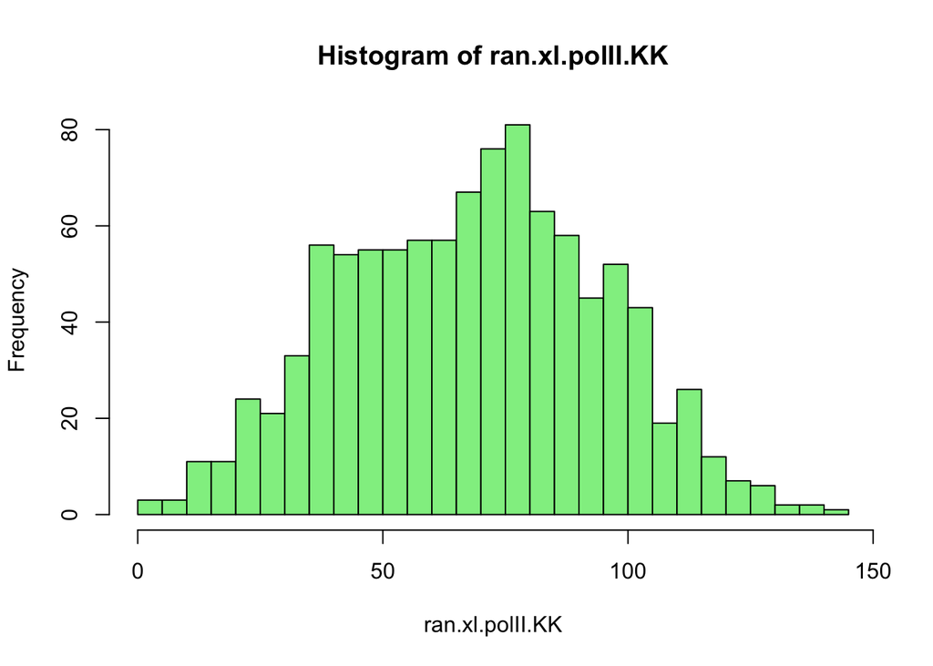

```r
ran.xl.polII.KK <- getRandomCrosslinks(polII, numCrosslinks=1000)
hist(ran.xl.polII.KK, breaks=25, col="lightgreen")
```

Mean Random K-K distance (Å):

```r
mean(ran.xl.polII.KK)
```

```
## [1] 68.2396
```

Standard deviation (Å):

```r
sd(ran.xl.polII.KK)
```

```
## [1] 26.23838
```

#### Use cases 2) Distribution of random Asp/Glu crosslinks of RNA pol II:

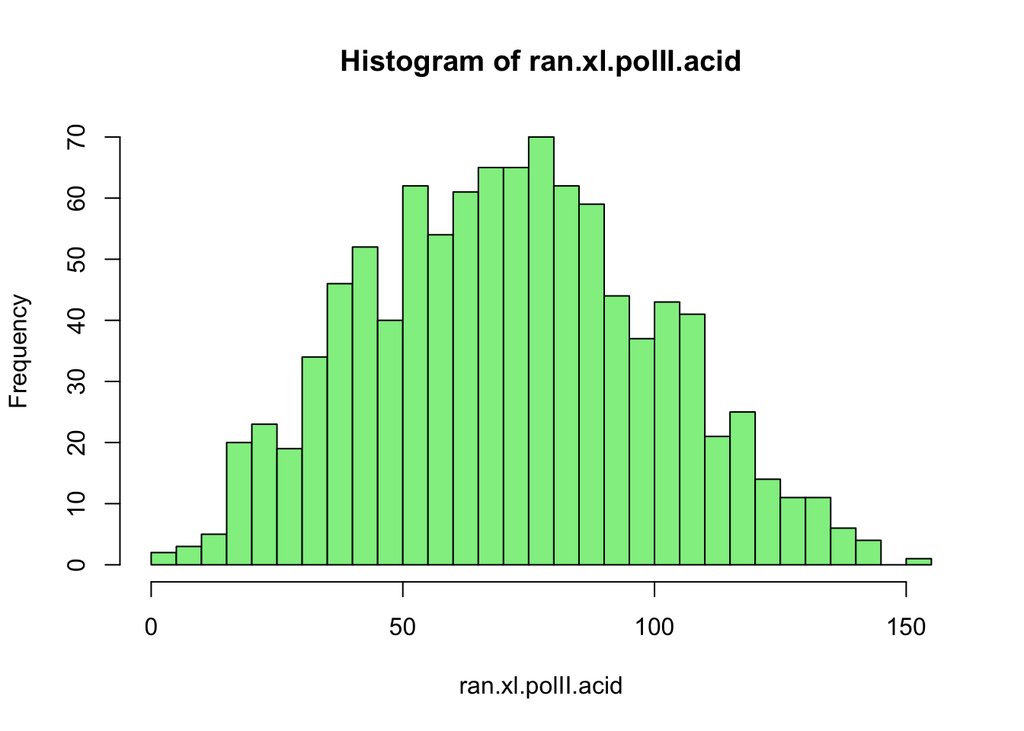

```r
ran.xl.polII.acid <- getRandomCrosslinks(polII, numCrosslinks=1000,
                                     resType1 = c("GLU", "ASP"),
                                     resType2 = c("GLU", "ASP"))
hist(ran.xl.polII.acid, breaks=25, col="lightgreen")
```

Mean Random D/E-D/E distance (Å):

```r
mean(ran.xl.polII.acid)
```

```
## [1] 71.40916
```

Standard deviation (Å):

```r
sd(ran.xl.polII.acid)
```

```
## [1] 28.54847
```

#### Use cases 3) Distribution of random Lys -> Asp/Gly crosslinks of RNA pol II limited to Rpb5/Rpb6 (chains E and F in pdb file):

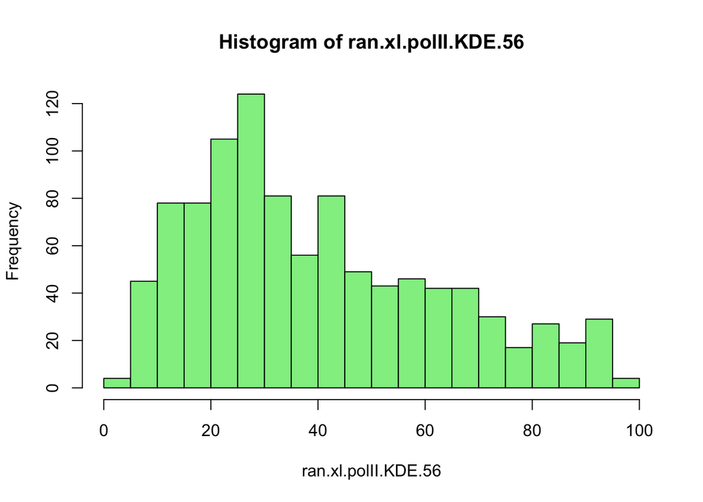

```r
ran.xl.polII.KDE.56 <- getRandomCrosslinks(polII, numCrosslinks=1000,
                                     resType1 = "LYS",
                                     resType2 = c("GLY", "ASP"),
                                     chains = c("E", "F"))
hist(ran.xl.polII.KDE.56, breaks=25, col="lightgreen")
```

```r
mean(ran.xl.polII.KDE.56)
```

```
## [1] 39.90371
```

Std Dev

```r
sd(ran.xl.polII.KDE.56)
```

```
## [1] 22.91066
```

The output of the getRandomCrosslinks function is a numeric vector of values. To write to a text file:

```r
write(ran.xl.polII.KK, "randomPolIIxlinks.txt")
```